# Taller EDA

Marisol Víquez Rivera y Fernando Contreras Artavia

2025-12-04

```r
tinytex::uninstall_tinytex()
tinytex::install_tinytex()
```

```
## tlmgr --repository http://www.preining.info/tlgpg/ install tlgpg
```

```
## tlmgr option repository "https://mirrors.ucr.ac.cr/CTAN/systems/texlive/tlnet"
```

```
## tlmgr update --list
```

```r
View(datos)
```

```r
datos <- read.csv("Calificaciones.csv")

cat("Filas:", nrow(datos), "— Columnas:", ncol(datos), "\n")
```

```
## Filas: 2000 — Columnas: 7
```

```r
head(datos)
```

|  | Student_ID | Attendance.... | Internal.Test.1..out.of.40. | Internal.Test.2..out.of.40. | Assignment.Score..out.of.10. | Daily.Study.Hours | Final.Exam.Marks..out.of.100. |
| --- | --- | --- | --- | --- | --- | --- | --- |
| 1 | S1000 | 84 | 30 | 36 | 7 | 3 | 72 |
| 2 | S1001 | 91 | 24 | 38 | 6 | 3 | 56 |
| 3 | S1002 | 73 | 29 | 26 | 7 | 3 | 56 |
| 4 | S1003 | 80 | 36 | 35 | 7 | 3 | 74 |
| 5 | S1004 | 84 | 31 | 37 | 8 | 3 | 66 |
| 6 | S1005 | 100 | 34 | 34 | 7 | 3 | 79 |

```r
tail(datos)
```

|  | Student_ID | Attendance.... | Internal.Test.1..out.of.40. | Internal.Test.2..out.of.40. | Assignment.Score..out.of.10. | Daily.Study.Hours | Final.Exam.Marks..out.of.100. |
| --- | --- | --- | --- | --- | --- | --- | --- |
| 1995 | S2994 | 97 | 40 | 38 | 9 | 4 | 81 |
| 1996 | S2995 | 82 | 31 | 28 | 6 | 2 | 52 |
| 1997 | S2996 | 78 | 38 | 27 | 7 | 2 | 57 |
| 1998 | S2997 | 78 | 30 | 33 | 9 | 2 | 61 |
| 1999 | S2998 | 82 | 29 | 40 | 8 | 3 | 59 |
| 2000 | S2999 | 97 | 32 | 38 | 7 | 3 | 64 |

```r
str(datos)
```

```
## 'data.frame':    2000 obs. of  7 variables:
##  $ Student_ID                   : chr  "S1000" "S1001" "S1002" "S1003" ...
##  $ Attendance....               : int  84 91 73 80 84 100 96 83 91 87 ...
##  $ Internal.Test.1..out.of.40.  : int  30 24 29 36 31 34 40 39 30 27 ...
##  $ Internal.Test.2..out.of.40.  : int  36 38 26 35 37 34 36 37 37 37 ...
##  $ Assignment.Score..out.of.10. : int  7 6 7 7 8 7 8 7 8 8 ...
##  $ Daily.Study.Hours            : int  3 3 3 3 3 3 3 3 2 3 ...
##  $ Final.Exam.Marks..out.of.100.: int  72 56 56 74 66 79 83 77 71 61 ...
```

```r
summary(datos)
```

```
##   Student_ID        Attendance....   Internal.Test.1..out.of.40.
##  Length:2000        Min.   : 52.00   Min.   :18.00
##  Class :character   1st Qu.: 80.00   1st Qu.:29.00
##  Mode  :character   Median : 85.00   Median :32.00
##                     Mean   : 84.89   Mean   :32.12
##                     3rd Qu.: 90.00   3rd Qu.:35.00
##                     Max.   :100.00   Max.   :40.00
##  Internal.Test.2..out.of.40. Assignment.Score..out.of.10. Daily.Study.Hours
##  Min.   :16.00               Min.   : 4.000               Min.   :1.000
##  1st Qu.:29.00               1st Qu.: 7.000               1st Qu.:2.000
##  Median :33.00               Median : 8.000               Median :3.000
##  Mean   :32.46               Mean   : 7.507               Mean   :2.824
##  3rd Qu.:36.00               3rd Qu.: 8.000               3rd Qu.:3.000
##  Max.   :40.00               Max.   :10.000               Max.   :5.000
##  Final.Exam.Marks..out.of.100.
##  Min.   : 25.00
##  1st Qu.: 58.00
##  Median : 65.00
##  Mean   : 64.86
##  3rd Qu.: 73.00
##  Max.   :100.00
```

```r
colnames(datos) <- c(
  "id",
  "asis",
  "ex1",
  "ex2",
  "tareas",
  "horas",
  "final"
)

colSums(is.na(datos))
```

```
##     id   asis    ex1    ex2 tareas  horas  final
##      0      0      0      0      0      0      0
```

```r
sum(is.na(datos))
```

```
## [1] 0
```

```r
media <- mean(datos$final)
mediana <- median(datos$final)
tabla_freq <- table(round(datos$final, 0))
moda <- as.numeric(names(tabla_freq)[which.max(tabla_freq)])

media
```

```
## [1] 64.855
```

```r
mediana
```

```
## [1] 65
```

```r
moda
```

```
## [1] 66
```

```r
varianza <- var(datos$final)
desv <- sd(datos$final)
cuartiles <- quantile(datos$final, probs = c(.25, .5, .75))
rango <- max(datos$final) - min(datos$final)

varianza
```

```
## [1] 128.6243
```

```r
desv
```

```
## [1] 11.34126
```

```r
cuartiles
```

```
## 25% 50% 75%
##  58  65  73
```

```r
rango
```

```
## [1] 75
```

```r
# Contar valores NA en cada columna
colSums(is.na(datos))
```

```
##     id   asis    ex1    ex2 tareas  horas  final
##      0      0      0      0      0      0      0
```

```r
# Total de valores faltantes
cat("Total de valores faltantes:", sum(is.na(datos)), "\n")
```

```
## Total de valores faltantes: 0
```

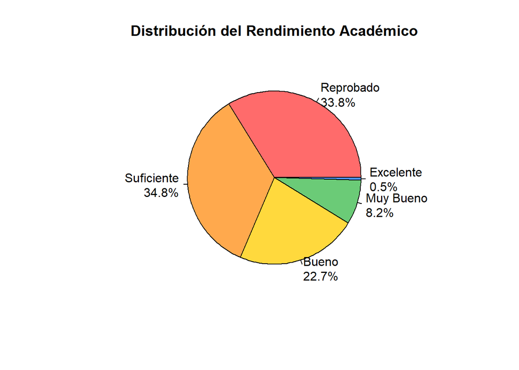

```r
datos$rend <- cut(
  datos$final,
  breaks = c(0, 60, 70, 80, 90, 100),
  labels = c("Reprobado","Suficiente","Bueno","Muy Bueno","Excelente"),
  include.lowest = TRUE
)

frecuencias <- table(datos$rend)
porcentajes <- round(prop.table(frecuencias) * 100, 1)
etiquetas <- paste(names(frecuencias), "\n", porcentajes, "%", sep = "")

pie(
  frecuencias,
  labels = etiquetas,
  col = c("#FF6B6B","#FFA94D","#FFD93D","#6BCB77","#4D96FF"),
  main = "Distribución del Rendimiento Académico"
)
```

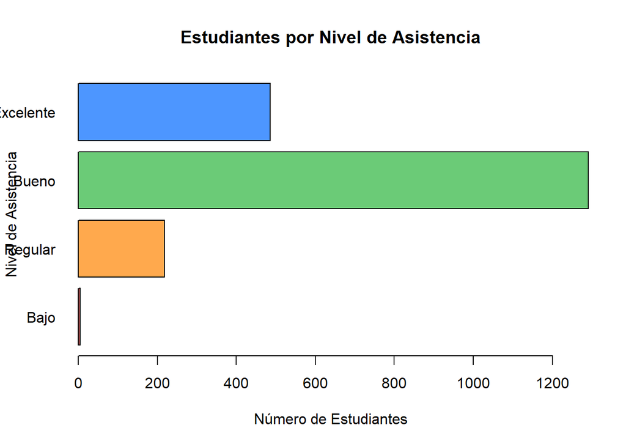

```r
# Crear categorías de asistencia usando la columna correcta: asis
datos$nivel_as <- cut(
  datos$asis,
  breaks = c(0, 60, 75, 90, 100),
  labels = c("Bajo", "Regular", "Bueno", "Excelente"),
  include.lowest = TRUE
)

# Convertir a factor con niveles fijos (para que siempre aparezcan las etiquetas)
datos$nivel_as <- factor(
  datos$nivel_as,
  levels = c("Bajo", "Regular", "Bueno", "Excelente")
)

# Frecuencias
freq_asistencia <- table(datos$nivel_as)

# Gráfico de barras horizontal
barplot(
  freq_asistencia,
  horiz = TRUE,
  col = c("#FF6B6B", "#FFA94D", "#6BCB77", "#4D96FF"),
  main = "Estudiantes por Nivel de Asistencia",
  xlab = "Número de Estudiantes",
  ylab = "Nivel de Asistencia",
  las = 1
)
```

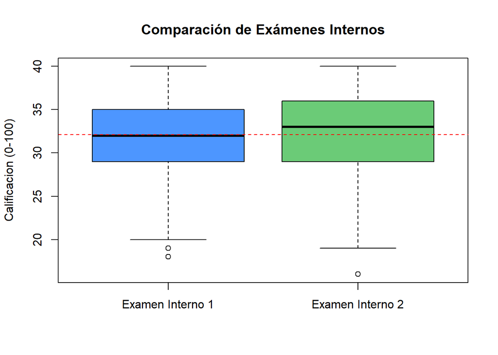

```r
boxplot(
  datos$ex1, datos$ex2,
  names = c("Examen Interno 1","Examen Interno 2"),
  col = c("#4D96FF","#6BCB77"),
  main = "Comparación de Exámenes Internos",
  ylab = "Calificacion (0-100)"
)

abline(h = mean(datos$ex1), col = "red", lty = 2)
```

```r
# ================================
# Estadísticas del Examen Interno 1
# ================================
cat("=== EXAMEN INTERNO 1 ===\n")
```

```
## === EXAMEN INTERNO 1 ===
```

```r
cat("Media:", round(mean(datos$ex1), 2), "\n")
```

```
## Media: 32.12
```

```r
cat("Mediana:", round(median(datos$ex1), 2), "\n")
```

```
## Mediana: 32
```

```r
cat("Desv. Est.:", round(sd(datos$ex1), 2), "\n\n")
```

```
## Desv. Est.: 4.56
```

```r
# ================================
# Estadísticas del Examen Interno 2
# ================================
cat("=== EXAMEN INTERNO 2 ===\n")
```

```
## === EXAMEN INTERNO 2 ===
```

```r
cat("Media:", round(mean(datos$ex2), 2), "\n")
```

```
## Media: 32.46
```

```r
cat("Mediana:", round(median(datos$ex2), 2), "\n")
```

```
## Mediana: 33
```

```r
cat("Desv. Est.:", round(sd(datos$ex2), 2), "\n\n")
```

```
## Desv. Est.: 4.52
```

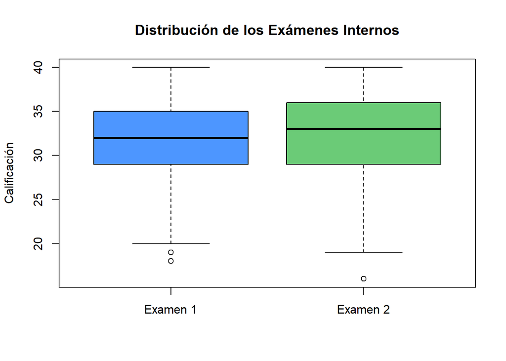

```r
boxplot(
  datos$ex1,
  datos$ex2,
  names = c("Examen 1", "Examen 2"),
  col = c("#4D96FF", "#6BCB77"),
  main = "Distribución de los Exámenes Internos",
  ylab = "Calificación"
)
```

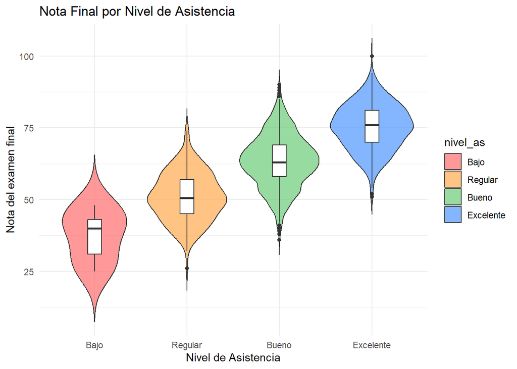

```r
ggplot(datos, aes(x = nivel_as, y = final, fill = nivel_as)) +
  geom_violin(trim = FALSE, alpha = .7) +
  geom_boxplot(width = .15, fill = "white") +
  scale_fill_manual(values = c("#FF6B6B","#FFA94D","#6BCB77","#4D96FF")) +
  theme_minimal() +
  labs(title = "Nota Final por Nivel de Asistencia",
       x = "Nivel de Asistencia",
       y = "Nota del examen final"
       )
```

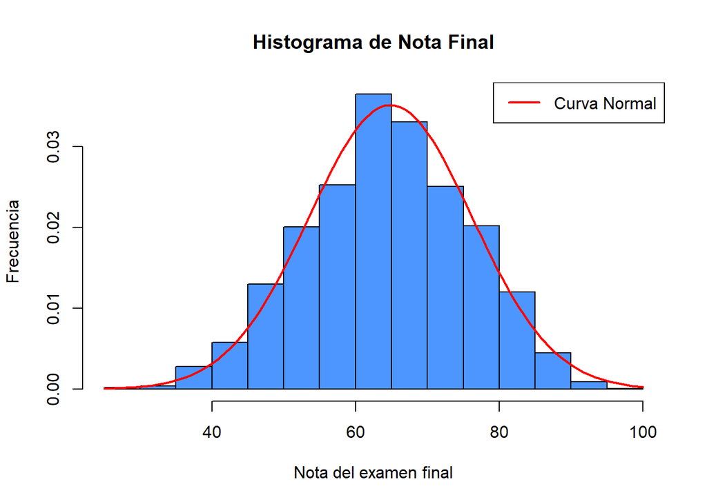

```r
# 7.1 Histograma
hist(
  datos$final,
  breaks = 20,
  col = "#4D96FF",
  freq = FALSE,
  main = "Histograma de Nota Final",
  xlab = "Nota del examen final",
  ylab = "Frecuencia"
)

curve(
  dnorm(x, mean = mean(datos$final), sd = sd(datos$final)),
  add = TRUE,
  col = "red",
  lwd = 2
)

legend("topright",
 legend = "Curva Normal",
 col = "red",
 lwd = 2)
```

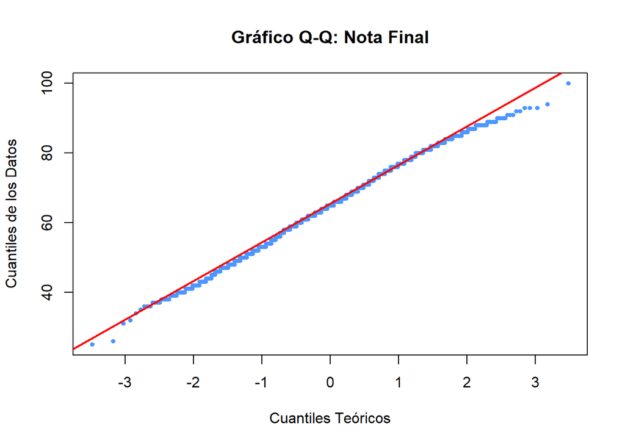

```r
# Crear gráfico Q-Q para la variable final
qqnorm(
  datos$final,
  main = "Gráfico Q-Q: Nota Final",
  xlab = "Cuantiles Teóricos",
  ylab = "Cuantiles de los Datos",
  col = "#4D96FF",
  pch = 19,
  cex = 0.6
)

# Agregar línea de referencia
qqline(datos$final, col = "red", lwd = 2)
```

```r
shapiro.test(datos$final)
```

```
##
##  Shapiro-Wilk normality test
##
## data:  datos$final
## W = 0.99664, p-value = 0.0002191
```

```r
# Prueba de Shapiro-Wilk
# NOTA: Esta prueba funciona mejor con menos de 5000 datos
shapiro_test <- shapiro.test(datos$final)

cat("=== PRUEBA DE SHAPIRO-WILK ===\n")
```

```
## === PRUEBA DE SHAPIRO-WILK ===
```

```r
cat("Estadístico W:", round(shapiro_test$statistic, 4), "\n")
```

```
## Estadístico W: 0.9966
```

```r
cat("Valor p:", shapiro_test$p.value, "\n")
```

```
## Valor p: 0.0002190907
```

```r
# Interpretación del resultado
if (shapiro_test$p.value > 0.05) {
  cat("Conclusión: Los datos SON NORMALES (p > 0.05)\n")
} else {
  cat("Conclusión: Los datos NO SON NORMALES (p <= 0.05)\n")
}
```

```
## Conclusión: Los datos NO SON NORMALES (p <= 0.05)
```

```r
# Prueba de Kolmogorov-Smirnov
# Primero se estandarizan los datos
datos_std <- (datos$final - mean(datos$final)) / sd(datos$final)

ks_test <- ks.test(datos_std, "pnorm")
cat("=== PRUEBA DE KOLMOGOROV-SMIRNOV ===\n")
```

```
## === PRUEBA DE KOLMOGOROV-SMIRNOV ===
```

```r
cat("Estadístico D:", round(ks_test$statistic, 4), "\n")
```

```
## Estadístico D: 0.029
```

```r
cat("Valor p:", ks_test$p.value, "\n")
```

```
## Valor p: 0.06953239
```

```r
# Interpretación del resultado
if (ks_test$p.value > 0.05) {
  cat("Conclusión: Los datos SON NORMALES (p > 0.05)\n")
} else {
  cat("Conclusión: Los datos NO SON NORMALES (p <= 0.05)\n")
}
```

```
## Conclusión: Los datos SON NORMALES (p > 0.05)
```

```r
vars_numericas <- datos[, c("asis", "ex1", "ex2", "tareas", "horas", "final")]

matriz_cor <- cor(vars_numericas)

round(matriz_cor, 2)
```

```
##        asis  ex1  ex2 tareas horas final
## asis   1.00 0.51 0.49   0.43  0.30  0.73
## ex1    0.51 1.00 0.26   0.57  0.21  0.69
## ex2    0.49 0.26 1.00   0.54  0.23  0.69
## tareas 0.43 0.57 0.54   1.00  0.17  0.67
## horas  0.30 0.21 0.23   0.17  1.00  0.41
## final  0.73 0.69 0.69   0.67  0.41  1.00
```

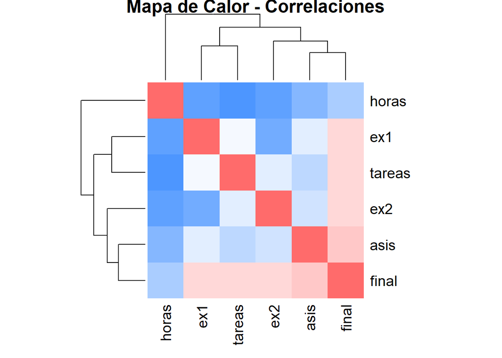

```r
heatmap(
  matriz_cor,
  col = colorRampPalette(c("#4D96FF", "white", "#FF6B6B"))(20),
  symm = TRUE,
  main = "Mapa de Calor - Correlaciones"
)
```

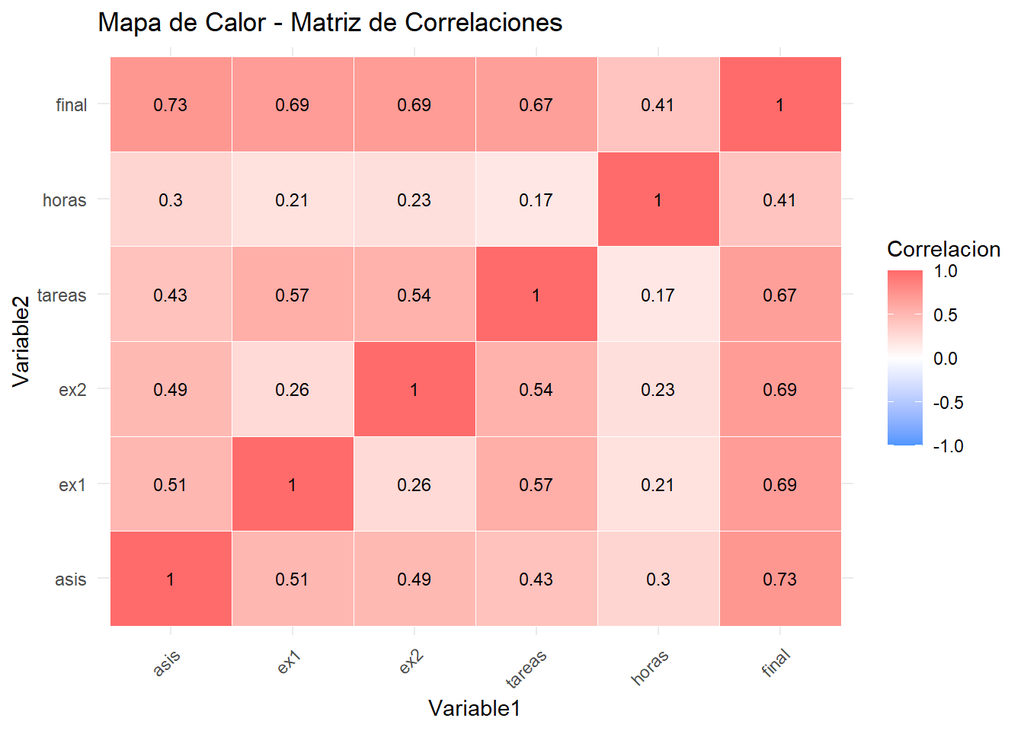

```r
library(reshape2)

matriz_largo <- melt(matriz_cor)
colnames(matriz_largo) <- c("Variable1", "Variable2", "Correlacion")

ggplot(matriz_largo, aes(x = Variable1, y = Variable2, fill = Correlacion)) +
  geom_tile(color = "white") +
  geom_text(aes(label = round(Correlacion, 2)), size = 3) +
  scale_fill_gradient2(low = "#4D96FF", mid = "white", high = "#FF6B6B",
                       midpoint = 0, limit = c(-1, 1)) +
  labs(title = "Mapa de Calor - Matriz de Correlaciones") +
  theme_minimal() +
  theme(axis.text.x = element_text(angle = 45, hjust = 1))
```

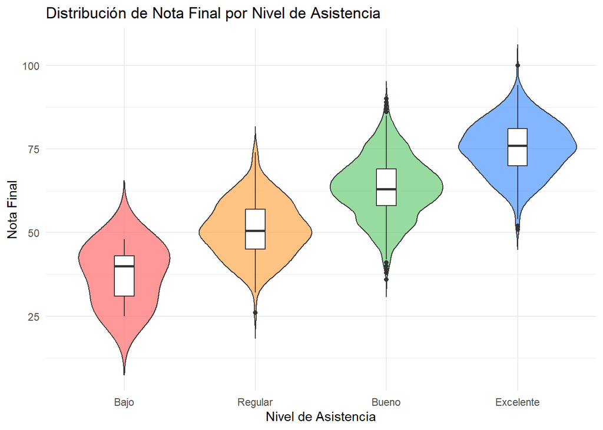

```r
ggplot(datos, aes(x = nivel_as, y = final, fill = nivel_as)) +
  geom_violin(trim = FALSE, alpha = 0.7) +
  geom_boxplot(width = 0.15, fill = "white") +
  scale_fill_manual(values = c("#FF6B6B", "#FFA94D", "#6BCB77", "#4D96FF")) +
  labs(
    title = "Distribución de Nota Final por Nivel de Asistencia",
    x = "Nivel de Asistencia",
    y = "Nota Final"
  ) +
  theme_minimal() +
  theme(legend.position = "none")
```

```r
vars_numericas <- datos[, c("asis", "ex1", "ex2", "tareas", "horas", "final")]
matriz_cor <- cor(vars_numericas)
round(matriz_cor, 2)
```

```
##        asis  ex1  ex2 tareas horas final
## asis   1.00 0.51 0.49   0.43  0.30  0.73
## ex1    0.51 1.00 0.26   0.57  0.21  0.69
## ex2    0.49 0.26 1.00   0.54  0.23  0.69
## tareas 0.43 0.57 0.54   1.00  0.17  0.67
## horas  0.30 0.21 0.23   0.17  1.00  0.41
## final  0.73 0.69 0.69   0.67  0.41  1.00
```

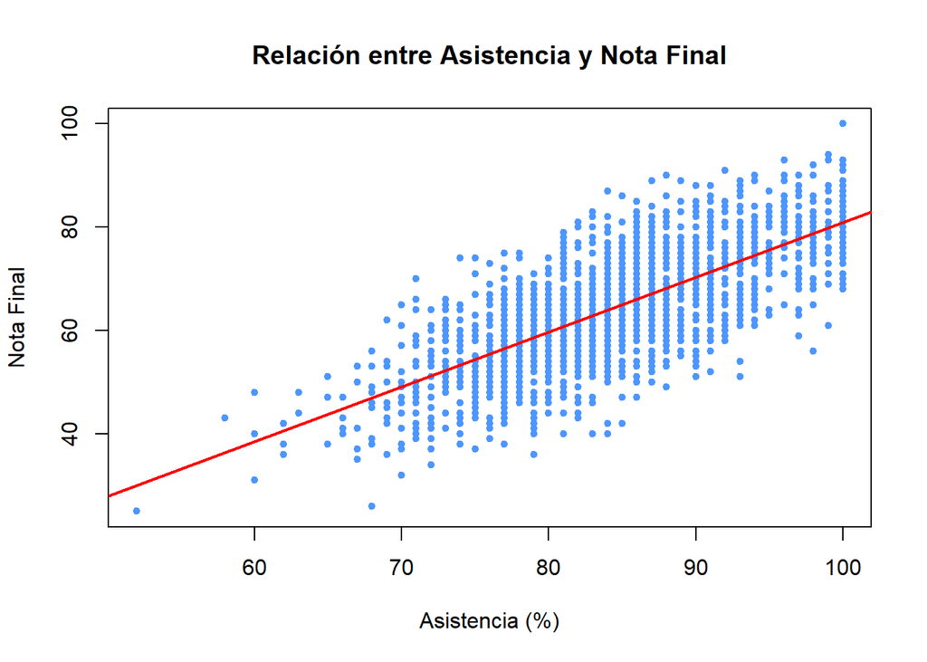

```r
plot(
  datos$asis,
  datos$final,
  main = "Relación entre Asistencia y Nota Final",
  xlab = "Asistencia (%)",
  ylab = "Nota Final",
  col = "#4D96FF",
  pch = 19,
  cex = 0.7
)

abline(lm(final ~ asis, data = datos), col = "red", lwd = 2)
```

```r
correlacion <- cor(datos$asis, datos$final)
cat("Coeficiente de correlación (r):", round(correlacion, 4), "\n")
```

```
## Coeficiente de correlación (r): 0.7256
```

```r
prueba_cor <- cor.test(datos$asis, datos$final)
cat("Valor p:", prueba_cor$p.value, "\n")
```

```
## Valor p: 0
```

```r
if(prueba_cor$p.value < 0.05) {
  cat("La correlación ES estadísticamente significativa\n")
} else {
  cat("La correlación NO es significativa\n")
}
```

```
## La correlación ES estadísticamente significativa
```

```r
modelo <- lm(final ~ asis, data = datos)
summary(modelo)
```

```
##
## Call:
## lm(formula = final ~ asis, data = datos)
##
## Residuals:
##      Min       1Q   Median       3Q      Max
## -23.9094  -5.4021   0.1196   5.4230  23.0906
##
## Coefficients:
##             Estimate Std. Error t value Pr(>|t|)
## (Intercept) -25.1883     1.9181  -13.13   <2e-16 ***
## asis          1.0607     0.0225   47.14   <2e-16 ***
## ---
## Signif. codes:  0 '***' 0.001 '**' 0.01 '*' 0.05 '.' 0.1 ' ' 1
##
## Residual standard error: 7.806 on 1998 degrees of freedom
## Multiple R-squared:  0.5266, Adjusted R-squared:  0.5263
## F-statistic:  2222 on 1 and 1998 DF,  p-value: < 2.2e-16
```

```r
intercepto <- coef(modelo)[1]
pendiente <- coef(modelo)[2]

cat("=== ECUACIÓN DEL MODELO ===\n")
```

```
## === ECUACIÓN DEL MODELO ===
```

```r
cat("final =", round(intercepto, 2), "+", round(pendiente, 2), "* asis\n\n")
```

```
## final = -25.19 + 1.06 * asis
```

```r
r_cuadrado <- summary(modelo)$r.squared
cat("R²:", round(r_cuadrado, 4), "\n")
```

```
## R²: 0.5266
```

```r
cat("Esto significa que la asistencia explica el",
    round(r_cuadrado * 100, 1), "% de la variabilidad en la nota final.\n")
```

```
## Esto significa que la asistencia explica el 52.7 % de la variabilidad en la nota final.
```

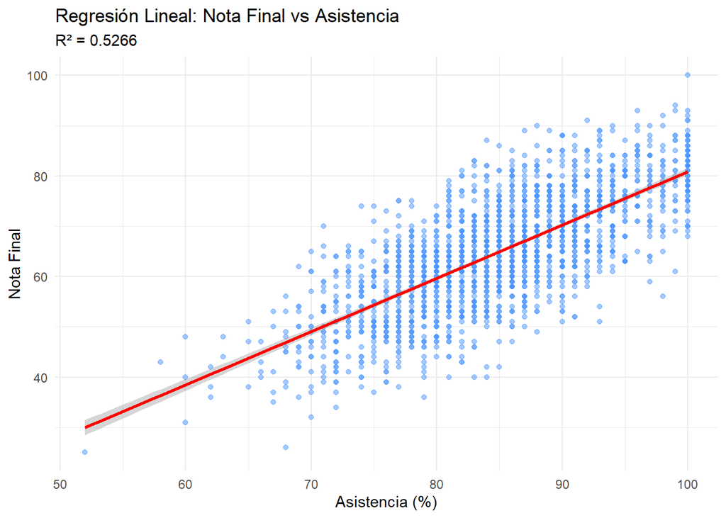

```r
ggplot(datos, aes(x = asis, y = final)) +
  geom_point(color = "#4D96FF", alpha = 0.5) +
  geom_smooth(method = "lm", color = "red", se = TRUE) +
  labs(
    title = "Regresión Lineal: Nota Final vs Asistencia",
    subtitle = paste("R² =", round(r_cuadrado, 4)),
    x = "Asistencia (%)",
    y = "Nota Final"
  ) +
  theme_minimal()
```

```r
nuevos_datos <- data.frame(
  asis = c(60, 70, 80, 90, 100)
)

predicciones <- predict(modelo, newdata = nuevos_datos)

cat("=== PREDICCIONES ===\n")
```

```
## === PREDICCIONES ===
```

```r
for(i in 1:5) {
  cat("Si la asistencia es", nuevos_datos$asis[i],
      "% → Nota predicha:",
      round(predicciones[i], 1), "\n")
}
```

```
## Si la asistencia es 60 % → Nota predicha: 38.5
## Si la asistencia es 70 % → Nota predicha: 49.1
## Si la asistencia es 80 % → Nota predicha: 59.7
## Si la asistencia es 90 % → Nota predicha: 70.3
## Si la asistencia es 100 % → Nota predicha: 80.9
```

```r
mi_prediccion <- data.frame(asis = 85)
resultado <- predict(modelo, newdata = mi_prediccion)
cat("Nota predicha para 85% de asistencia:", round(resultado, 1), "\n")
```

```
## Nota predicha para 85% de asistencia: 65
```

Actividad 1. Dimensiones del conjunto de datos

Número de filas: 2000 Número de columnas: 7

Conclusión: El conjunto de datos contiene 2000 observaciones y 7 variables. Estas dimensiones permiten realizar un análisis estadístico confiable y estable, con suficientes casos para detectar patrones y tendencias relevantes.

Actividad 2. Datos faltantes

Total de valores faltantes: 0

Conclusión: El dataset no presenta valores perdidos. Esto elimina la necesidad de realizar imputaciones y permite trabajar directamente con todos los registros sin procesos de limpieza adicionales relacionados con NA.

Actividad 3. Estadísticos descriptivos de la variable “Nota Final”

Media: 64.855

Mediana: 65

Moda: 66

Varianza: 128.6243

Desviación estándar: 11.34126

Rango: 75

Mínimo: 25

Máximo: 100

Conclusión: La Nota Final presenta una distribución amplia (rango de 75 puntos) con una media cercana a 65. La similitud entre la media y la mediana indica una distribución relativamente simétrica, aunque con dispersión moderada según la desviación estándar.

Actividad 4. Categorías de rendimiento (Gráfico de pastel)

Distribución de estudiantes por categoría:

Reprobado: 33.8 %

Suficiente: 34.8 %

Bueno: 22.7 %

Muy bueno: 8.2 %

Excelente: 0.5 %

La categoría con mayor cantidad de estudiantes es: Suficiente (34.8 %).

El porcentaje de estudiantes reprobados es: 33.8 %.

Actividad 5. Nivel de asistencia (Gráfico de barras horizontales)

Distribución por nivel:

Bajo: 5 estudiantes

Regular: 218

Bueno: 1291

Excelente: 486

Respuestas solicitadas:

Estudiantes con asistencia excelente: 486.

Nivel con menor cantidad de estudiantes: Bajo (5 estudiantes).

Actividad 6. Boxplots de los Exámenes Internos

Examen Interno 1:

Media: 32.12

Mediana: 32

Desviación estándar: 4.56

Outliers detectados (p. intercuartílico): 8

Examen Interno 2:

Media: 32.46

Mediana: 33

Desviación estándar: 4.52

Outliers detectados: 1

Respuestas solicitadas:

El examen con mayor mediana es el Examen Interno 2 (mediana = 33).

El examen con mayor dispersión es el Examen Interno 1 (desviación estándar = 4.56).

Existen outliers en ambos exámenes: 8 en Examen Interno 1 y 1 en Examen Interno 2.

Actividad 7. Gráfico de violín: Nota Final por nivel de asistencia

Estadísticas por categoría:

Bajo: media ≈ 37.4, mediana ≈ 40

Regular: media ≈ 50.95, mediana ≈ 50.5

Bueno: media ≈ 63.39, mediana ≈ 63

Excelente: media ≈ 75.27, mediana ≈ 76

Respuestas solicitadas:

El nivel de asistencia con mayor concentración (menor dispersión) es Excelente.

El nivel con notas más altas es Excelente.

Conclusión: existe una relación clara y positiva entre el nivel de asistencia y la Nota Final. Los grupos con mayor asistencia obtienen sistemáticamente mejores resultados.

Actividad 8. Análisis de normalidad

Prueba de Shapiro–Wilk:

p = 0.0002191

Conclusión: se rechaza la hipótesis de normalidad.

Prueba Kolmogorov–Smirnov (datos estandarizados):

p ≈ 0.06953

Conclusión: no se rechaza la normalidad.

Conclusión general: Los resultados son mixtos. Mientras que Shapiro–Wilk indica falta de normalidad, KS no rechaza la hipótesis. Al evaluar conjuntamente los resultados y el gráfico Q-Q, la variable Nota Final no sigue una distribución perfectamente normal. Esto sugiere que la distribución presenta leves desviaciones en las colas.

Actividad 9. Matriz de correlación y mapa de calor

Correlaciones principales con la Nota Final:

asis: 0.73

ex1: 0.69

ex2: 0.69

tareas: 0.67

horas: 0.41

Respuestas solicitadas:

La correlación más alta se da entre asis y final (0.73).

No existe correlación negativa entre las variables analizadas.

La asistencia es la variable que mejor predice la Nota Final.

Actividad 10. Regresión lineal simple

Modelo ajustado: final = -25.19 + 1.06 × asis

Resultados relevantes:

R² = 0.5266

Coeficiente de asis altamente significativo (p < 2e−16)

La asistencia predice significativamente la Nota Final.

El modelo explica aproximadamente el 52.7 % de la variabilidad en la Nota Final.

Interpretación: por cada 1 % adicional de asistencia, la Nota Final aumenta en aproximadamente 1.06 puntos.

Actividad 11. Predicción

Predicciones del modelo:

60 % de asistencia → 38.5 puntos

70 % → 49.1

80 % → 59.7

90 % → 70.3

100 % → 80.9

Predicción solicitada: Asistencia del 85 % → Nota Final predicha ≈ 65 puntos.